# iris데이터 설명 및 분석 방법

분석에 앞서 설치해야 하는 패키지를 설명하겠습니다.

- 이 코드를 이용하려면 설치해야 하는 패키지들입니다.
  - install.packages(“class”)
  - install.packages(“tree”)
  - install.packages(“nnet”)
  - install.packages(“ggplot2”)
- 업데이트는 패키지가 실행이 안될 때, 적용하시면 됩니다.
  - update.packages(‘class’)
- KNN기법을 이용하기 위해 설치해야 하는 패키지들입니다.
  - library(class)
- Decision tree기법을 이용하기 위해 설치해야 하는 패키지들입니다.
  - library(tree)
- Multinomial logistic regression(다항 로지스틱 회귀분석)기법을 이용하기 위해 설치해야 하는 패키지들입니다.
  - library(nnet)
- 그래프을 그리기 위해 설치해야 하는 패키지들입니다.
  - library(ggplot2)
- sample로 인해 생기는 랜덤 변수를 고정해주었습니다.(seed 고정)
  - set.seed(999)
- 그래프 설명을 위해 환경설정을 하겠습니다.

```r
library(class)
library(tree)
library(nnet)
library(ggplot2)
set.seed(999)
```

- iris 데이터 설명한 링크입니다.
  - https://thebook.io/006723/ch04/01/
- iris데이터의 구조

```r
str(iris)
```

```
## 'data.frame':    150 obs. of  5 variables:
##  $ Sepal.Length: num  5.1 4.9 4.7 4.6 5 5.4 4.6 5 4.4 4.9 ...
##  $ Sepal.Width : num  3.5 3 3.2 3.1 3.6 3.9 3.4 3.4 2.9 3.1 ...
##  $ Petal.Length: num  1.4 1.4 1.3 1.5 1.4 1.7 1.4 1.5 1.4 1.5 ...
##  $ Petal.Width : num  0.2 0.2 0.2 0.2 0.2 0.4 0.3 0.2 0.2 0.1 ...
##  $ Species     : Factor w/ 3 levels "setosa","versicolor",..: 1 1 1 1 1 1 1 1 1 1 ...
```

- iris데이터의 산점도

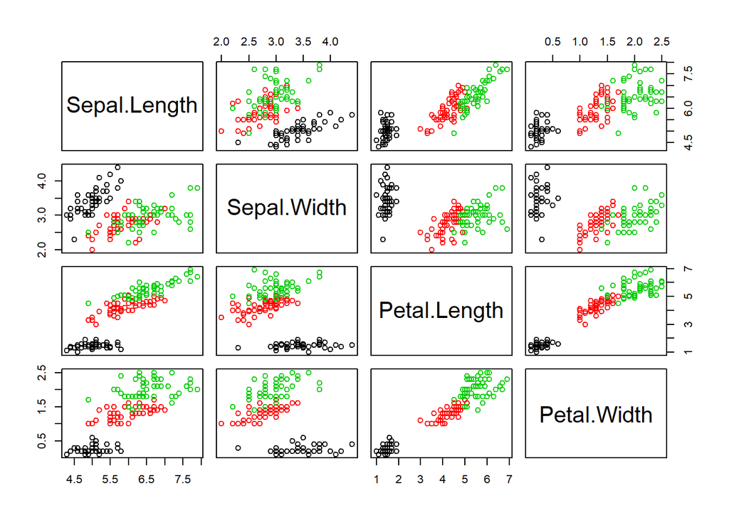

```r
plot(iris[,1:4],col=iris$Species)
```

- iris데이터 정보를 나타내줍니다.(Summary)

```r
summary(iris)
```

```
##   Sepal.Length    Sepal.Width     Petal.Length    Petal.Width
##  Min.   :4.300   Min.   :2.000   Min.   :1.000   Min.   :0.100
##  1st Qu.:5.100   1st Qu.:2.800   1st Qu.:1.600   1st Qu.:0.300
##  Median :5.800   Median :3.000   Median :4.350   Median :1.300
##  Mean   :5.843   Mean   :3.057   Mean   :3.758   Mean   :1.199
##  3rd Qu.:6.400   3rd Qu.:3.300   3rd Qu.:5.100   3rd Qu.:1.800
##  Max.   :7.900   Max.   :4.400   Max.   :6.900   Max.   :2.500
##        Species
##  setosa    :50
##  versicolor:50
##  virginica :50
##
##
##
```

```r
View(iris)
```

- 데이터의 시각화를 위해서 값들을 범주형으로 변경했습니다.

```r
iris_fac = floor(iris[,1:4]*2)
iris_fac$Species = iris$Species
iris_fac
```

```
##     Sepal.Length Sepal.Width Petal.Length Petal.Width    Species
## 1             10           7            2           0     setosa
## 2              9           6            2           0     setosa
## 3              9           6            2           0     setosa
## 4              9           6            3           0     setosa
## 5             10           7            2           0     setosa
## 6             10           7            3           0     setosa
## 7              9           6            2           0     setosa
## 8             10           6            3           0     setosa
## 9              8           5            2           0     setosa
## 10             9           6            3           0     setosa
## 11            10           7            3           0     setosa
## 12             9           6            3           0     setosa
## 13             9           6            2           0     setosa
## 14             8           6            2           0     setosa
```

[output cut: 136 more lines]

```r
iris_fac$Sepal.Length = as.factor(iris_fac$Sepal.Length)
iris_fac$Sepal.Width = as.factor(iris_fac$Sepal.Width)
iris_fac$Petal.Length = as.factor(iris_fac$Petal.Length)
iris_fac$Petal.Width = as.factor(iris_fac$Petal.Width)
```

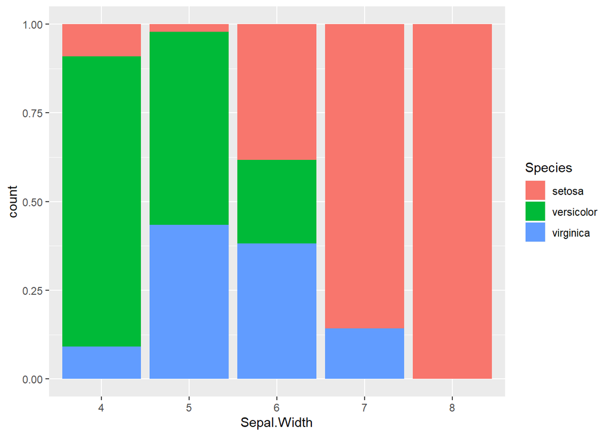

```r
p <- ggplot(iris_fac,aes(Sepal.Width,fill=Species))+geom_bar(position='fill')
p
```

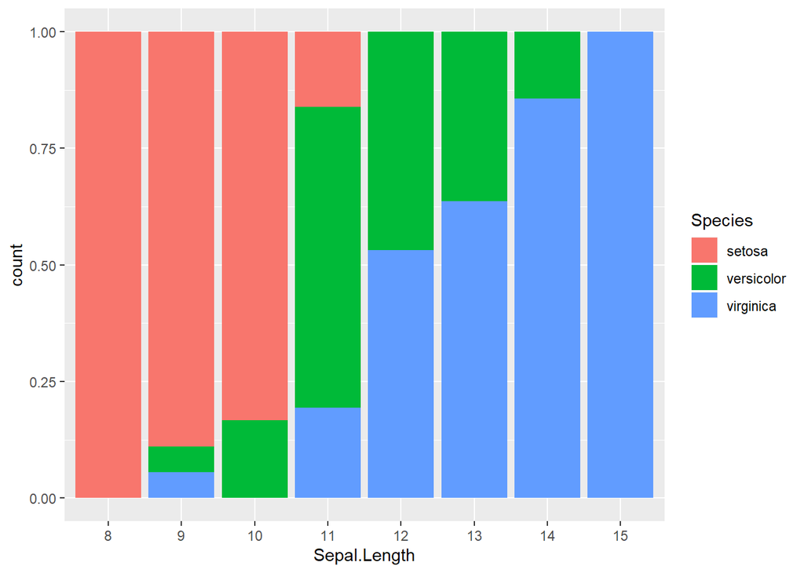

```r
p <- ggplot(iris_fac,aes(Sepal.Length,fill=Species))+geom_bar(position='fill')
p
```

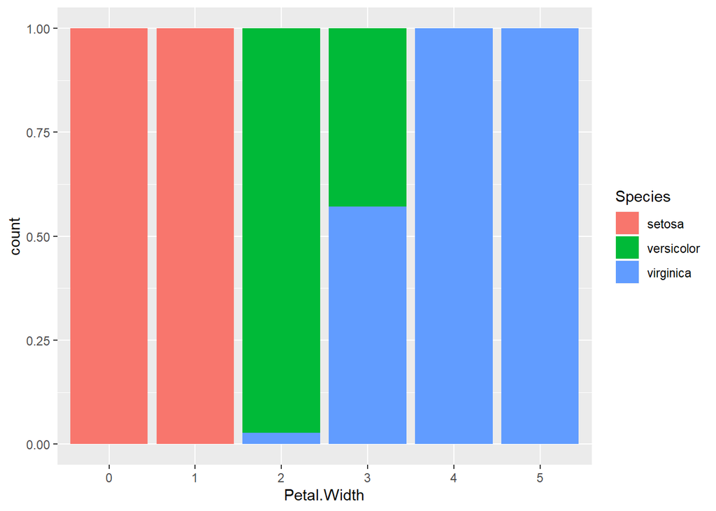

```r
p <- ggplot(iris_fac,aes(Petal.Width,fill=Species))+geom_bar(position='fill')
p
```

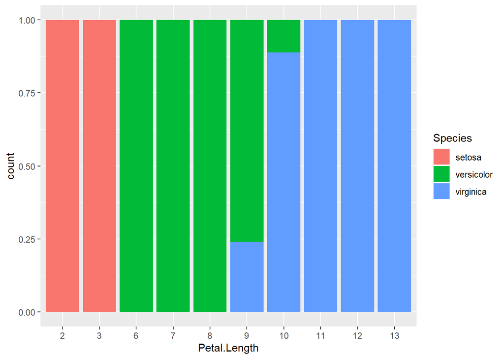

```r
p <- ggplot(iris_fac,aes(Petal.Length,fill=Species))+geom_bar(position='fill')
p
```

결과 : 모든 feature가 y값에 중요한 것으로 판단됩니다.

- 다른 분석기법을 적용하기 위해 trainset를 설정합니다.
- testset 분리 비율은 7 : 3 으로 했습니다. 데이터가 150개 밖에 되지 않아 조금 비율을 많이 설정했습니다.

```r
idx <- sample(c('train','test'),nrow(iris),replace = TRUE, prob = c(0.7,0.3))
iris_train <- iris[idx == 'train',]
iris_test <- iris[idx == 'test',]

nrow(iris_train)
```

```
## [1] 107
```

```r
nrow(iris_test)
```

```
## [1] 43
```

```r
iris_train_x <- iris_train[,1:4]
iris_train_y <- iris_train[,5]

iris_test_x <- iris_test[,1:4]
iris_test_y <- iris_test[,5]
```

- Decision tree model에 적용합니다.

```r
iris_treemodel <- tree(iris_train$Species ~., data = iris_train)
predict_tree <- predict(iris_treemodel, iris_test, type = 'class')
table(iris_test_y, predict_tree)
```

```
##             predict_tree
## iris_test_y  setosa versicolor virginica
##   setosa         14          0         0
##   versicolor      0         13         0
##   virginica       0          4        12
```

```r
mean(iris_test_y == predict_tree)
```

```
## [1] 0.9069767
```

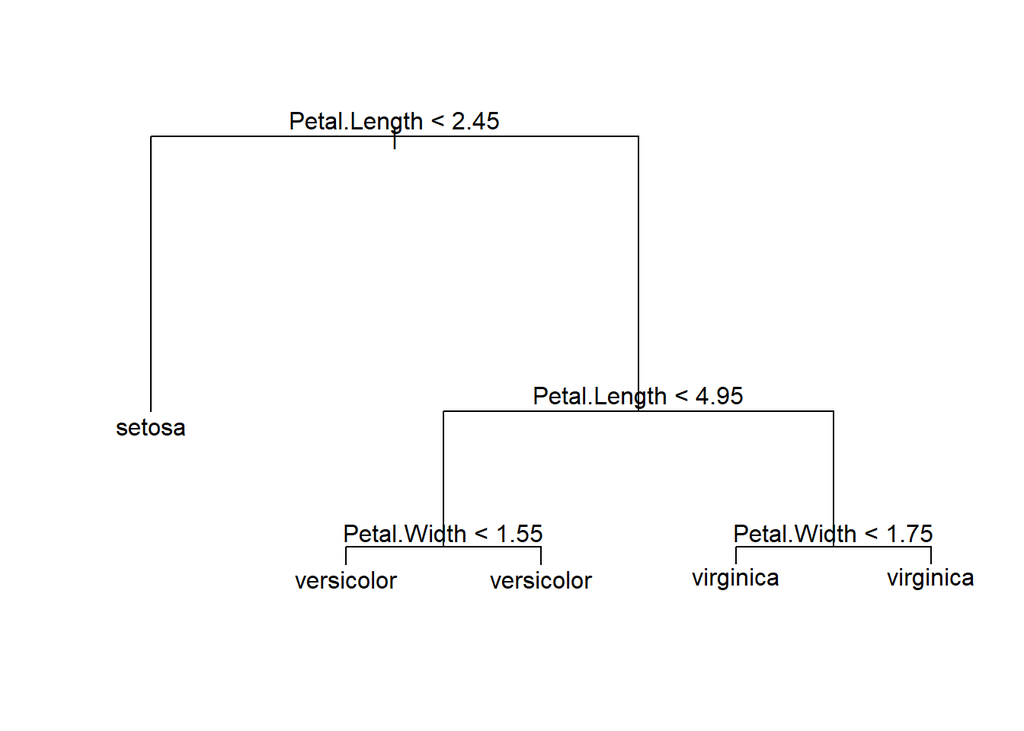

```r
plot(iris_treemodel)
text(iris_treemodel)
```

- test모델과 Decision tree model에 적용시킨 모델을 비교해봅니다.

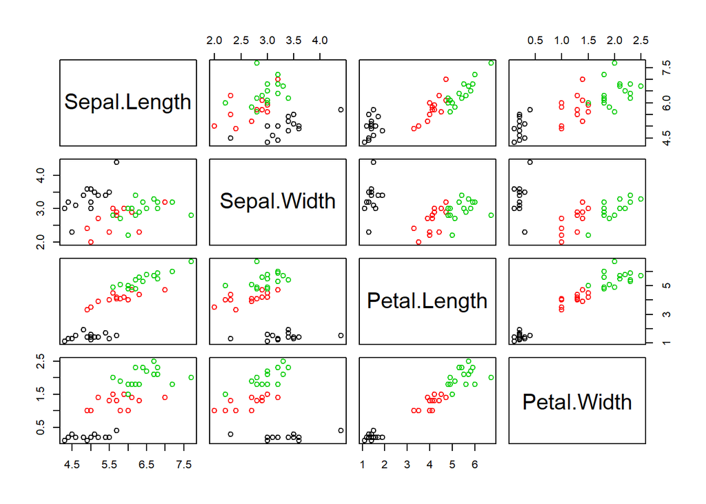

```r
plot(iris_test_x, col = iris_test_y)
```

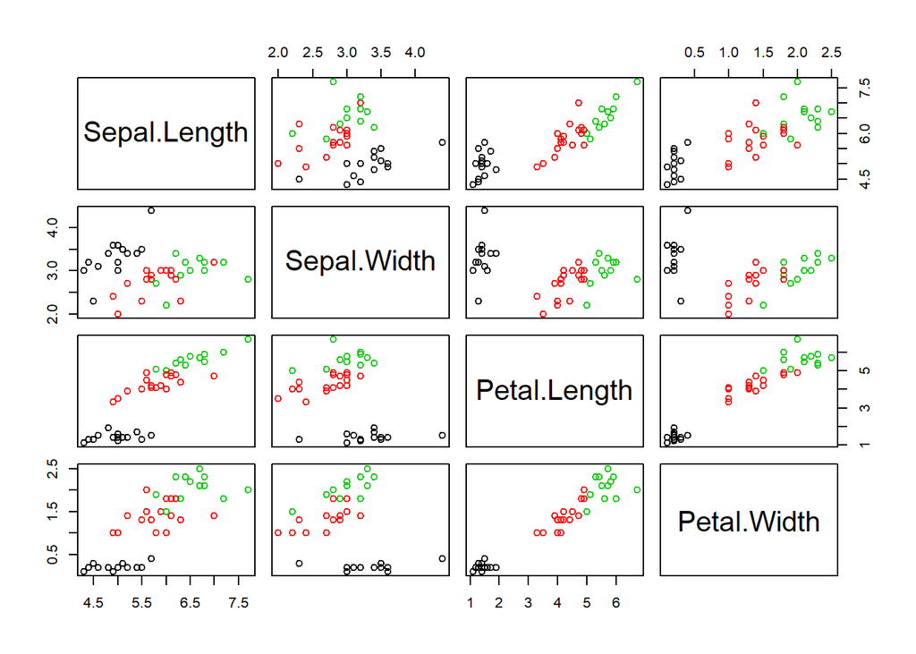

```r
plot(iris_test_x, col = predict_tree)
```

- iris 데이터를 정규화시킵니다.

```r
iris_scale <- as.data.frame(scale(iris[,1:4]))
iris_scale$Species <- iris$Species
```

- train데이터와 test데이터를 만들어줍니다.
  - idx <- sample(c(‘train’,‘test’),nrow(iris),replace = TRUE, prob = c(0.7,0.3))입니다.

```r
iris_scale_train <- iris_scale[idx == 'train',]
iris_scale_test <- iris_scale[idx == 'test',]

iris_scale_train_x <- iris_scale_train[,1:4]
iris_scale_train_y <- iris_scale_train[,5]

iris_scale_test_x <- iris_scale_test[,1:4]
iris_scale_test_y <- iris_scale_test[,5]
```

- KNN model를 적용시킵니다.

```r
predict_knn <- knn(train = iris_scale_train_x, test = iris_scale_test_x, cl = iris_scale_train_y, k = 3)
table(iris_scale_test_y, predict_knn)
```

```
##                  predict_knn
## iris_scale_test_y setosa versicolor virginica
##        setosa         14          0         0
##        versicolor      0         13         0
##        virginica       0          3        13
```

```r
mean(iris_scale_test_y == predict_knn)
```

```
## [1] 0.9302326
```

- test모델과 KNN model에 적용시킨 모델을 비교해봅니다.

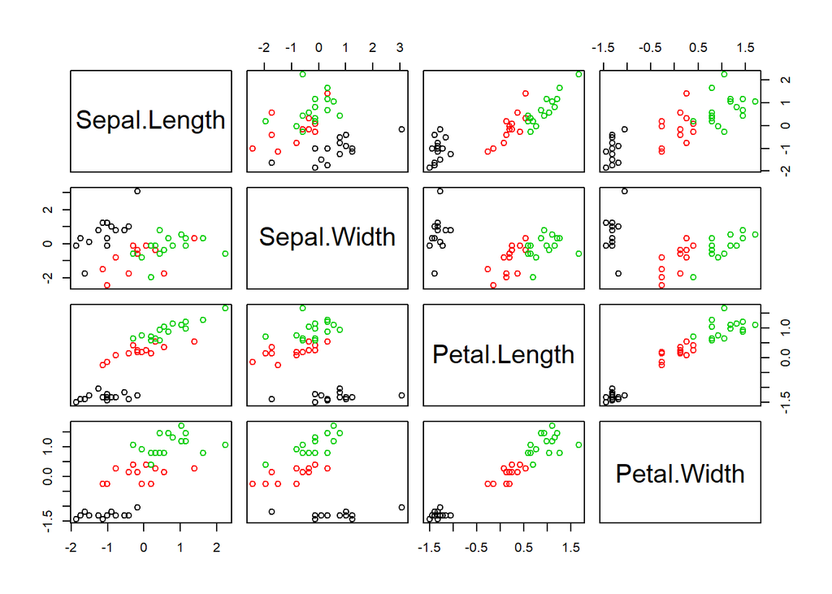

```r
plot(iris_scale_test_x, col = iris_scale_test_y)
```

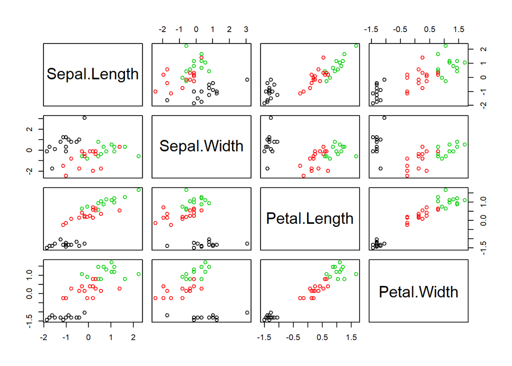

```r
plot(iris_scale_test_x, col = predict_knn)
```

- Multinomial logistic model(다항 로지스틱 회귀분석)기법을 적용시킵니다.

```r
iris_multinom <- multinom(iris_scale_train$Species ~., data = iris_scale_train)
predict_multinom <- predict(iris_multinom, iris_scale_test, type = 'class')
table(iris_scale_test_y, predict_multinom)
```

```
##                  predict_multinom
## iris_scale_test_y setosa versicolor virginica
##        setosa         14          0         0
##        versicolor      0         13         0
##        virginica       0          1        15
```

```r
mean(iris_scale_test_y == predict_multinom)
```

```
## [1] 0.9767442
```

- test모델과 Multinomial logistic model(다항 로지스틱 회귀분석)에 적용시킨 모델을 비교해봅니다.

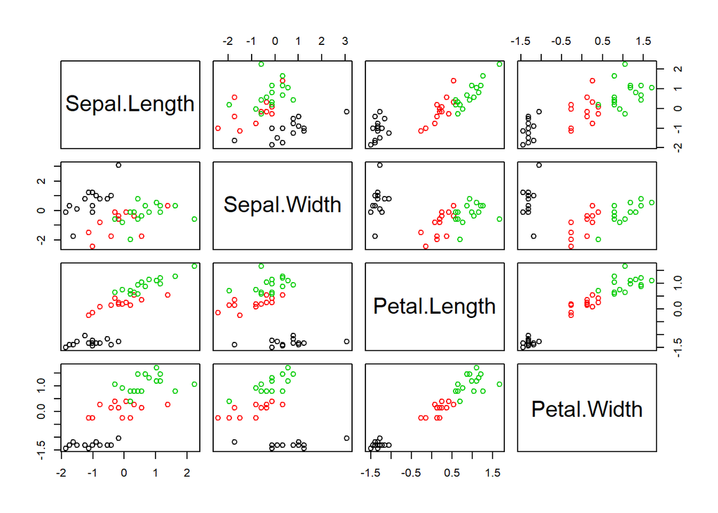

```r
plot(iris_scale_test_x, col = iris_scale_test_y)
```

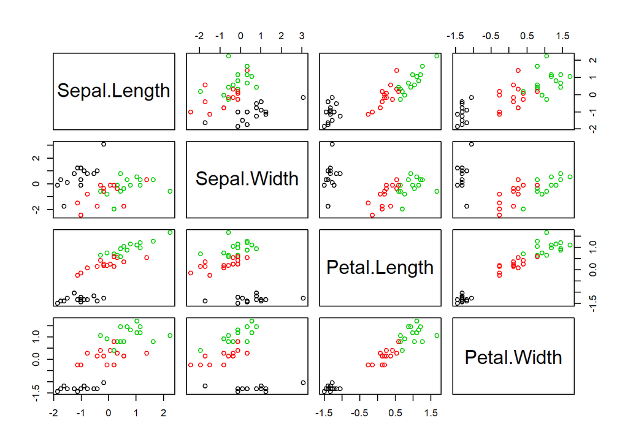

```r
plot(iris_scale_test_x, col = predict_multinom)
```